# Table of Contents

```python
import numpy as np
import pandas as pd
```

# 7.3 String Manipulation

pandas adds to the mix by enabling you to apply string and regular expressions concisely on whole arrays of data, additionally handling the annoyance of missing data.

## String Object Methods

As an example, a comma-separated string can be broken into pieces with `split`:

```python
val = 'a,b, guido'
val.split(',')
```

```
['a', 'b', ' guido']
```

`split` is often combined with `strip` to trim whitespace (including line breaks):

```python
pieces = [x.strip() for x in val.split(',')]
pieces
```

```
['a', 'b', 'guido']
```

These substrings could be concatenated together with a two-colon delimiter using addition:

```python
first, second, third = pieces
first + '::' + second + '::' + third
```

```
'a::b::guido'
```

A faster and more Pythonic way is to pass a list or tuple to the `join` method on the string '::':

```python
'::'.join(pieces)
```

```
'a::b::guido'
```

Using Python’s `in` keyword is the best way to detect a substring, though index and find can also be used:

```python
'guido' in val
```

```
True
```

```python
val.index(',')
```

```
1
```

```python
val.find(':')
```

```
-1
```

Note the difference between `find` and `index` is that `index` raises an exception if the string isn’t found (versus returning –1):

```python
val.index(':')
```

```
---------------------------------------------------------------------------
ValueError                                Traceback (most recent call last)
<ipython-input-9-2c016e7367ac> in <module>
----> 1 val.index(':')

ValueError: substring not found
```

Relatedly, count returns the number of occurrences of a particular substring:

```python
val.count(',')
```

```
2
```

replace will substitute occurrences of one pattern for another.

```python
val.replace(',', '::')
```

```
'a::b:: guido'
```

```python
val.replace(',', '')
```

```
'ab guido'
```

#### See Table 7-3 for a listing of some of Python’s string methods

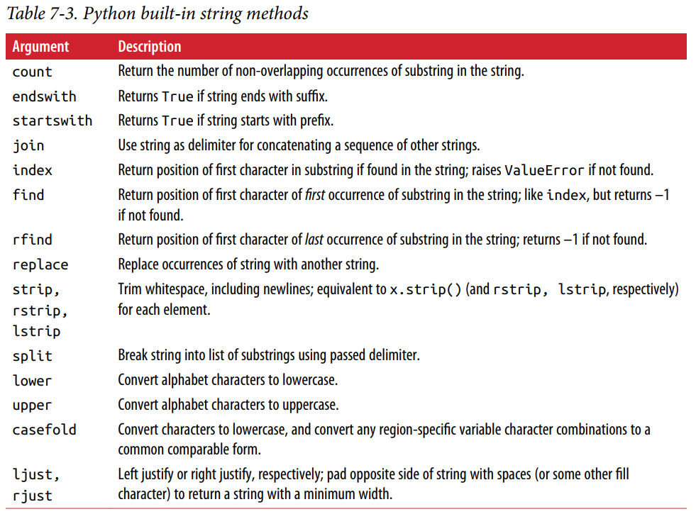

## Regular Expressions

Regular expressions provide a flexible way to search or match (often more complex) string patterns in text.

- The re module functions fall into three categories: **pattern matching, substitution, and splitting.**
- Let’s look at a simple example: suppose we wanted to split a string with a variable number of whitespace characters (tabs, spaces, and newlines). The regex describing one or more whitespace characters is `\s+`:

```python
import re
text = "foo bar\t baz \tqux"
re.split('\s+', text)
```

```
['foo', 'bar', 'baz', 'qux']
```

- The regular expression is first compiled, and then its split method is called on the passed text
- You can compile the regex yourself with `re.compile`

```python
regex = re.compile('\s+')
regex.split(text)
```

```
['foo', 'bar', 'baz', 'qux']
```

If, instead, you wanted to get a list of all patterns matching the regex, you can use the `findall` method:

```python
regex.findall(text)
```

```
[' ', '\t ', ' \t']
```

Creating a regex object with re.compile is highly recommended if you intend to apply the same expression to many strings; doing so will save CPU cycles.

- `findall` returns all matches in a string
- `search` returns only the first match.
- `match` only matches at the beginning of the string.

```python
text = """Dave dave@google.com
Steve steve@gmail.com
Rob rob@gmail.com
Ryan ryan@yahoo.com
"""
pattern = r'[A-Z0-9._%+-]+@[A-Z0-9.-]+\.[A-Z]{2,4}'
# re.IGNORECASE makes the regex case-insensitive
regex = re.compile(pattern, flags=re.IGNORECASE)
```

```python
regex.findall(text)
```

```
['dave@google.com', 'steve@gmail.com', 'rob@gmail.com', 'ryan@yahoo.com']
```

`search` returns a special match object for the first email address in the text.

```python
m = regex.search(text)
m
```

```
<re.Match object; span=(5, 20), match='dave@google.com'>
```

```python
text[m.start():m.end()]
```

```
'dave@google.com'
```

`regex.match` returns `None`, as it only will match if the pattern occurs at the start of the string:

```python
print(regex.match(text))
```

```
None
```

Relatedly, `sub` will return a new string with occurrences of the pattern replaced by the a new string

```python
print(regex.sub('REDACTED', text))
```

```
Dave REDACTED
Steve REDACTED
Rob REDACTED
Ryan REDACTED
```

Suppose you wanted to find email addresses and simultaneously segment each address into its three components: username, domain name, and domain suffix. **To do this, put parentheses around the parts of the pattern to segment:**

```python
pattern = r'([A-Z0-9._%+-]+)@([A-Z0-9.-]+)\.([A-Z]{2,4})'
regex = re.compile(pattern, flags=re.IGNORECASE)
```

A match object produced by this modified regex returns a tuple of the pattern components with its `groups` method:

```python
m = regex.match('wesm@bright.net')
m.groups()
```

```
('wesm', 'bright', 'net')
```

`findall` returns a list of tuples when the pattern has groups:

```python
regex.findall(text)
```

```
[('dave', 'google', 'com'),
 ('steve', 'gmail', 'com'),
 ('rob', 'gmail', 'com'),
 ('ryan', 'yahoo', 'com')]
```

`sub` also has access to groups in each match using special symbols like `\1` and `\2`. The symbol `\1` corresponds to the first matched group, `\2` corresponds to the second, and so forth:

```python
print(regex.sub(r'Username: \1, Domain: \2, Suffix: \3', text))
```

```
Dave Username: dave, Domain: google, Suffix: com
Steve Username: steve, Domain: gmail, Suffix: com
Rob Username: rob, Domain: gmail, Suffix: com
Ryan Username: ryan, Domain: yahoo, Suffix: com
```

#### Table 7-4 provides a brief summary

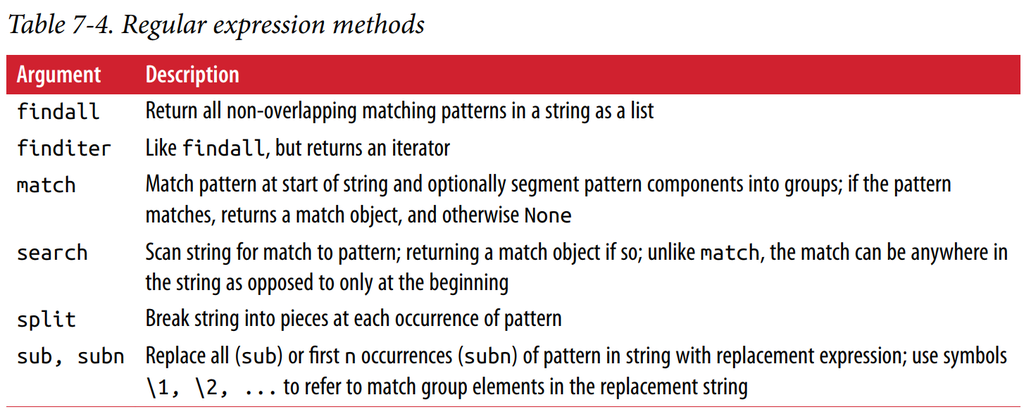

## Vectorized String Functions in pandas

Cleaning up a messy dataset for analysis often requires a lot of string munging and regularization.

```python
data = {'Dave': 'dave@google.com', 'Steve': 'steve@gmail.com','Rob': 'rob@gmail.com', 'Wes': np.nan}
data = pd.Series(data)
data
```

```
Dave     dave@google.com
Steve    steve@gmail.com
Rob        rob@gmail.com
Wes                  NaN
dtype: object
```

```python
data.isnull()
```

```
Dave     False
Steve    False
Rob      False
Wes       True
dtype: bool
```

You can apply string and regular expression methods can be applied (passing a lambda or other function) to each value using data.map, **but it will fail on the NA (null) values.**

```python
data.str.contains('gmail')
```

```
Dave     False
Steve     True
Rob       True
Wes        NaN
dtype: object
```

Regular expressions can be used, too, along with any re options like `IGNORECASE`:

```python
pattern
```

```
'([A-Z0-9._%+-]+)@([A-Z0-9.-]+)\\.([A-Z]{2,4})'
```

```python
data.str.findall(pattern, flags=re.IGNORECASE)
```

```
Dave     [(dave, google, com)]
Steve    [(steve, gmail, com)]
Rob        [(rob, gmail, com)]
Wes                        NaN
dtype: object
```

```python
matches = data.str.match(pattern, flags=re.IGNORECASE)
matches
```

```
Dave     True
Steve    True
Rob      True
Wes       NaN
dtype: object
```

#### See Table 7-5 for more pandas string methods.

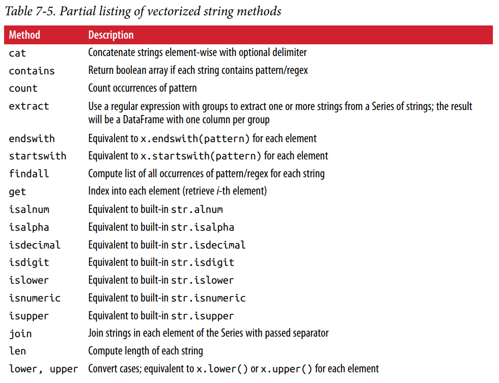

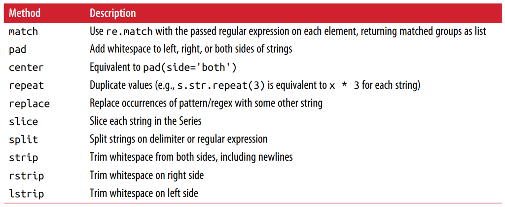